# Python für Umsteiger

```python
print("Hallo Welt")
```

# Über mich

- Lehrer an der CWS Usingen (Mathe/Informatik/demnächst: Darstellendes Spiel)
- Abgeordnet ans Schulportal (Moodle Theme)
- Wir unterrichten an der CWS seit 2018 in GK mit Python

# Python in der Sek II

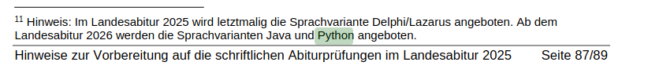

# Erfahrungen im Unterricht mit Python

- Man redet weniger über **syntaktische** Fehler und ist schneller bei **semantischen** Fehlern.
- Schüler haben mehr Erfolgserlebnisse
- Python lässt sich für verschiedene Themen verwenden (Objektorientierung, Web-Datenbank, KI, ...)

# Neue Erfahrungen für mich.

Python hat insbesondere in der Objektorientierung eine fundamental andere Herangehensweise als Java. Mein Blickwinkel auf Objektorientierung hat sich dadurch verändert.

Das Python-Zen:

```
  * Simple is better than complex
  * flat is better than nested
  * Readability counts
  * If the implementation ist hard to explain, it's a bad idea
  * If the implementation is easy to explain, it may be a good idea.
```

Jack Diderich - Stop Writing Classes

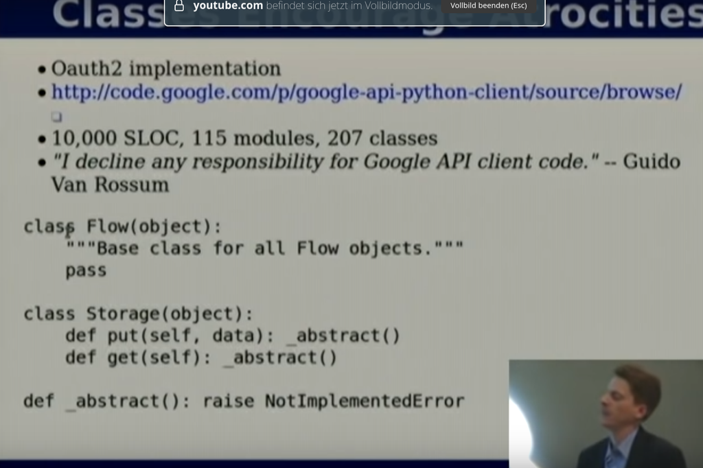

(https://youtu.be/o9pEzgHorH0)

...oder: https://steve-yegge.blogspot.com/2006/03/execution-in-kingdom-of-nouns.html

# Grundlagen

Auf einen Blick:

- Es gibt keine Semikolons `;`
- Variablen werden ohne Typen deklariert. `a = 3`
- Anstelle von Klammern `{}` bzw. `BEGIN END` starten Blöcke mit einem : und werden eingerückt.

  ```
  for i in range(4):
     print(i)
  ```

- Um Ausdrücke werden keine Klammern gesetzt.

  ```
  if i > 3:
      i = i + 1
  ```

```python
import turtle
turtle.forward(100)
turtle.mainloop() # not needed in Thonny
```

```python
import turtle
ben = turtle.Turtle()
ben.forward(100)
turtle.mainloop()
```

```python
# Welche IDE?
```

- Thonny ( https://thonny.org/ ) vollkommen ausreichend.
- Schüler nutzen oft selbst vscode oder pycharm

# Einrückung und Schleifen:

```python
import turtle
for _ in range(4):
    for _ in range(4):
        turtle.forward(50)
        turtle.right(90)
    turtle.penup()
    turtle.forward(60)
    turtle.pendown()

turtle.mainloop() # not needed: in Thonny
```

# Verzweigungen

```python
from random import randint

for _ in range(1000):
    x = randint(-100, 100)
    y = randint(-100, 100)
    turtle.penup()
    turtle.speed(0)
    turtle.setpos(x, y)
    turtle.pendown()
    if  x < 0 == 0:
        turtle.color("red")
        turtle.dot(3)
    elif x < 50:
        turtle.color("grey")
        turtle.dot(3)
    else:
        turtle.color("blue")
        turtle.dot(3)

turtle.mainloop() # not needed: in Thonny
```

# Textadventures

```python
end = False
state = "start"
while not end:
    if state == "start":
        text = "Du stehst vor der Sporthochschule - Wo gehst du hin?"
        choice = input(text)
        if choice == "t":
            state = "tagungsraum"
        elif choice == "q":
            end = True
    elif state == "tagungsraum":
        text = "Du bist im Tagungsraum"
        choice = input(text)
```

# Datentypen

Python ist dynamisch typisiert:

```python
x = 3
print(x)
print(type(x))
x = 4.0
print(type(x))
x = "4"
print(type(x))
```

```
3
<class 'int'>
<class 'float'>
<class 'str'>
```

```python
x = input("Gib die erste Variable an")
y = int(input("Gib die zweite Variable an"))
print(x + y)
```

```
---------------------------------------------------------------------------
TypeError                                 Traceback (most recent call last)
Cell In[3], line 3
      1 x = input("Gib die erste Variable an")
      2 y = int(input("Gib die zweite Variable an"))
----> 3 print(x + y)

TypeError: can only concatenate str (not "int") to str
```

## Datentypen und Operatoren

```
System.out.println("Ausgabe: " + 1);
```

---> "Ausgabe:1"

Pascal/Delphi

```
writeln('Ausgabe: ' + 1);
```

---> Error

Python verhält sich wie Pascal/Delphi:

```
print("1" + 1)
```

## Numerische Datentypen

- Es gibt nur `int`, `float` und `complex`
- Es gibt keine `maxint`-Eigenschaft

```python
lightyear_to_meter: int = 9460730472580800
milky_way_diameter = 100_000 * lightyear_to_meter

print(f"The milky way has a diameter of approximately {milky_way_diameter} meters")
```

```
The milky way has a diameter of approximately 946073047258080000000 meters
```

```python
Aber float-Werte können "überlaufen" - Es wird dann allerdings ein Fehler geworfen.
```

```python
a = 2.1
while a > 0:
    a = a ** 2
print(a)
```

```
---------------------------------------------------------------------------
OverflowError                             Traceback (most recent call last)
Cell In[5], line 3
      1 a = 2.1
      2 while a > 0:
----> 3     a = a ** 2
      4 print(a)

OverflowError: (34, 'Numerical result out of range')
```

# Boolean Datentypen

Man vergleicht booleans mit `and`, `or` und `not` Beispiel:

```
if not a and not b:
    do_something()
```

## Listen

- Python nutzt standardmäßig Listen im Gegensatz zu Delphi/Java (arrays)
- Listen können unterschiedliche Datentypen enthalten.
- Listen können dynamisch verlängert werden.

```python
a = [3, "Hallo Welt"]
for value in a:
    print(value)
```

```python
a.append("Noch ein Wert")
print(a)
```

## Listen - Spezielle Operationen:

```python
a = [3, "Hallo Welt"]

if (3 in a):
    print("Ok")
```

```python
a = [3, 4, 2]

if a:
    print("Die Liste ist nicht leer")
```

# Laufzeiten

In der Python-Dokumentation kann man die Laufzeiten für Listen-Operationen nachschlagen:

[figure not shown]

## Arrays

Theoretisch gibt es auch Arrays:

```python
import array
a = array.array('i', [10, 20, 30])
print(a)
print(a[1])
```

## List Comprehensions

```python
## List Comprehensions
lst = [x for x in range(0, 10) if x  % 2 == 0]
print(lst)
```

## Über Listen iterieren

Die Java-Variante `for (i=0;i<a.length;i++)` ist in Python nicht vorhanden, stattdessen:

```python
lst = range(0, 10)
for value in lst:
    print(value)
```

```python
lst = range(0, 10)
for index, value in enumerate(lst):
    print(index, value * value)
```

## Dictionaries

```python
telefonbuch = {"Stefan": 3213, "Klaus": 3212, "Stefan": 3021}
```

```python
print(telefonbuch["Stefan"])
```

# Funktionen

```python
def add(a, b, c = 0):
   return a + b + c

print(add(3, 4))
```

```python
  * Funktionen können Default-Parameter enthalten.
```

# Funktionen als "First Class-Objects"

```python
def add(a, b, c = 0):
   return a + b + c

def action(func, a, b, c = 0):
    return func(a, b, c)


print(action(add, 3, 4))
```

- Funktionen sind selbst auch Objekte und können als solche übergeben werden.

```python
print(type(add))
```

```python
a = add
a(3, 4)
```

# Objektorientierung

Ein einfaches Beispiel für eine Klasse.

```python
class BankAccount:
    def __init__(self):
        self.balance = 0

andreasKonto = BankAccount()
print(andreasKonto.value)
```

- `__init__` wird aufgerufen, **nachdem** die die Instanz instanziiert wird.

## Achtung: Typischer Fehler von Java-Umsteigern:

```python
class BankAccount:

    balance = 0

    def __init__(self):
        pass

andreasKonto = BankAccount()
martinKonto = BankAccount()
print(id(andreasKonto.balance), id(martinKonto.balance))
```

- `balance` ist hier eine Klassenvariable

## Methoden:

```python
class BankAccount:
    def __init__(self):
        self.balance = 0
        self.interest_rate = 0.03

    def deposit(self, balance):
        self.balance += balance

    def withdraw(self, balance):
        self.balance -= balance

    def add_interest(self):
        self.balance += self.balance * self.interest_rate



andreasKonto = BankAccount()
andreasKonto.deposit(20)
andreasKonto.add_interest()
print(andreasKonto.balance)
```

- Klassen werden im CamelCase geschrieben, Methoden mit snake_case.
- Es fehlt noch **Kapselung**...

# Kapselung - Teil 1

Python: Kapselung funktioniert anders als in Java und Delphi:

Mit **Properties** kann der Zugriff auf Attribute eingeschränkt werden - Der Rest der Klasse muss dafür nicht verändert werden!

```python
class BankAccount:
    def __init__(self, balance):
        self._balance = balance
        self.interest_rate = 0.03

    @property
    def balance(self):
        return self._balance

    @balance.setter
    def balance(self, value):
        self._balance = value

    def deposit(self, balance):
        self.balance += balance

    def withdraw(self, balance):
        self.balance -= balance

    def add_interest(self):
        self.balance += self.balance * self.interest_rate



andreasKonto = BankAccount(20)
andreasKonto.deposit(20)
andreasKonto.add_interest()
print(andreasKonto.balance)
```

[output not shown]

## Vergleich mit Java/Delphi:

Python verfolgt ein anderes Paradigma beim Entwurf des Systems:

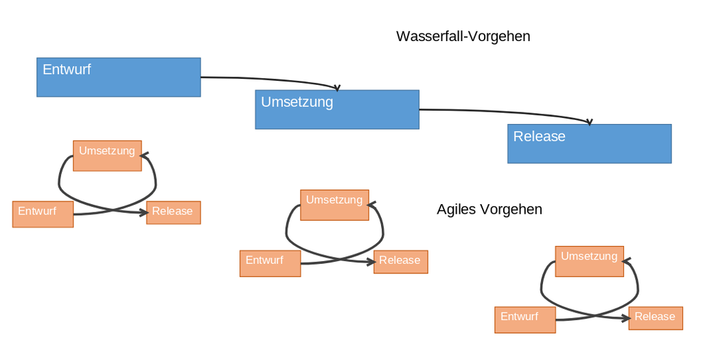

Idee Java/Delphi:

- Sichtbarkeiten werden im Voraus definiert
- Sichtbarkeiten sind **Regeln**, die auch von Programmiererinnen eingehalten werden müssen.

Idee Python:

- Es kann ein Prototyp erstellt werden, der ohne Sichtbarkeiten auskommt.
- Sichtbarkeiten können im Nachhinein hinzugefügt werden.
- Sichtbarkeit sind **Konventionen(!)**, auf die man sich geeinigt hat.
- Entwickler sind "erwachsene Leute".

# _ und __

Technisch sind dies die Entsprechungen für public/protected/private in Java:

```
self.attribute # public
self._attribute # protected
self.__attribute # private / name_mangling
```

**Aber**: In Python gilt nicht die Regel, dass alle Attribute private sein sollten. PEP8 sagt dazu:

*"Not everyone likes name mangling. Try to balance the need to avoid accidental name clashes with potential use by advanced callers."*

## Meine Herangehensweise

Im Grundkurs hat sich folgende Herangehensweise bewährt:

- `self._attribute` wird für private Attribute verwendet,
- `self.attribute` für öffentliche Attribute.
- Name Mangling habe ich bisher ausgeblendet.
- Properties habe ich exemplarisch verwendet, ansonsten einen eher Java-artigen Zugang zu Kapselung.

# Vererbung Interfaces

Es gibt keine Entsprechung für (Java) Interfaces in Python.

Aber Mehrfach-Vererbung:

```python
class Shape():
    pass

class Printable():
    def print(self):
        pass

class Rectangle(Shape, Printable):
    def __init__(self, x, y, width, height):
        self.x, self.y, self.width, self.height = x, y, width, height
    def print(self):
        return(self.x, self.y, self.width, self.height)

r = Rectangle(3, 5, 4, 2)
print(r.print())
```

```python
from abc import ABC, abstractmethod

class Shape(ABC):
    pass

class Printable(ABC):
    @abstractmethod
    def print(self):
        pass

class Rectangle(Shape, Printable):
    def __init__(self, x, y, width, height):
        self.x, self.y, self.width, self.height = x, y, width, height
    def print(self):
        return(self.x, self.y, self.width, self.height)

r = Rectangle(3, 5, 4, 2)
print(r.print())
```

# Type Hints

```python
from typing import Type

class Client:
    def __init__(self):
        self.partner = None

class SimpleNetwork:
    def __init__(self):
        self.client1 : Type[Client] = Client()
        self.client2 : Type[Client] = Client()

    def get_client1(self) -> Type[Client]:
        return self.client1

network =  SimpleNetwork()
print(type(network.client1))
print(network.get_client1())
```

# Mein Zugang zu Objektorientierung

## Miniworldmaker - Objects first

So sieht Code in der E-Phase aus:

```python
import miniworldmaker

board = miniworldmaker.Board()
r = miniworldmaker.Token((20, 20))
__
@r.register
def act(self):
    self.x += 1

@r.register
def on_key_pressed(self, keys):
    if 's' in keys:
        self.y = self.y +1

board.run()
```

[output not shown]

```
An exception has occurred, use %tb to see the full traceback.

SystemExit: 0
```

...und so in der Q-Phase:

```python
import miniworldmaker
import random

board = miniworldmaker.Board()

class MyToken(miniworldmaker.Token):

    def on_setup(self):
        self.x = random.randint(0,400)
        self.y = random.randint(0, 400)

    def act(self):
        self.x+= 1

    def on_key_pressed(self, keys):
        self.y = self.y + 1

for _ in range(10):
    MyToken()

board.run()
```

# GUI

Es gibt in Python viele GUIS: https://wiki.python.org/moin/GuiProgramming

- TKinter - Weit verbreitet
- guizero, pysimplegui, (appjar) - Gut geeignet im Bildungskontext.

## GuiZero

```python
from guizero import App, Text, PushButton, TextBox

def change_message():
    label.value = f"Hello {input_box.value}"

app = App(height= 130, width = 200, title="Hello world")
input_box = TextBox(app, width = 200)
button = PushButton(app, text="Press me", command=change_message)
label = Text(app, text="")
app.display()
```

## PySimpleGui

```python
import PySimpleGUI as sg

layout = [[sg.Text("What's your name?")],
          [sg.Input(key='-INPUT-')], # Define key '-INPUT'
          [sg.Text(size=(40,1), key='-OUTPUT-')], # Define key '-OUTPUT'
          [sg.Button('Ok'), sg.Button('Quit')]]

window = sg.Window('Window Title', layout)

while True:.
    event, values = window.read()
    if event == sg.WINDOW_CLOSED or event == 'Quit':
        break
    window['-OUTPUT-'].update(f"Hello {values['-INPUT-']}!")

window.close()
```

# tkinter

```python
import tkinter as tk

window = tk.Tk()

def update():
    global tk_label, tk_input
    tk_label["text"] = f"Hallo {tk_input.get()}"

tk_input = tk.Entry(window)
tk_input.pack()
tk_label = tk.Label(window, text="")
tk_label.pack()
tk_button = tk.Button(window, text = "Absenden", command=update)
tk_button.pack()

tk.mainloop()
```

# Unser Vorgehen

```python
  * Sehr projektorientiert
  * Begleitende Moodle-Kurse mit Code-Runner und neuerdings H5P
```

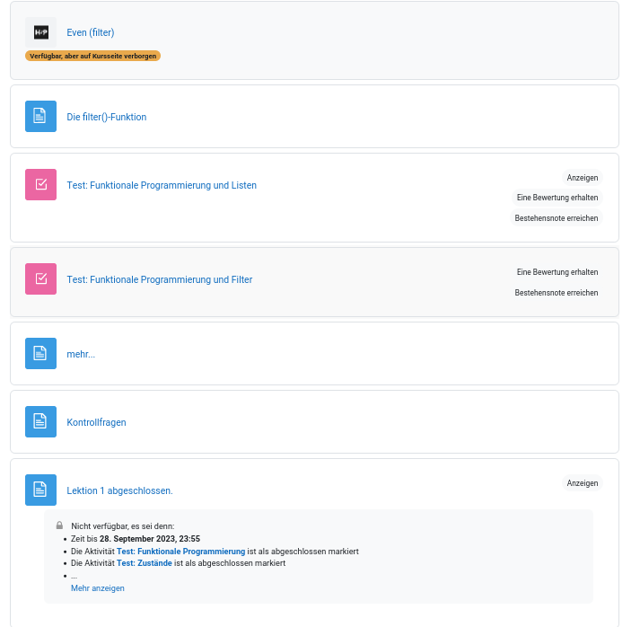

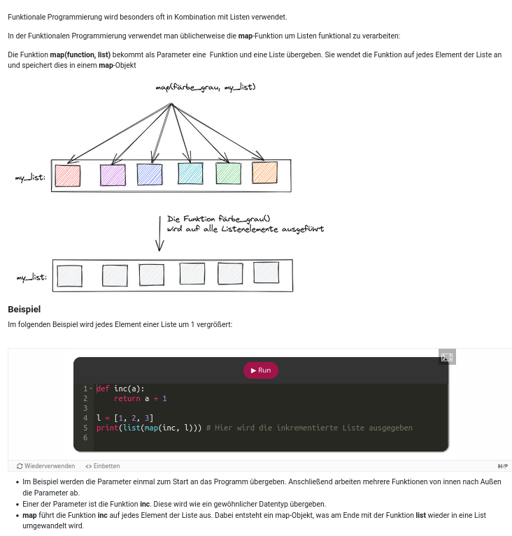

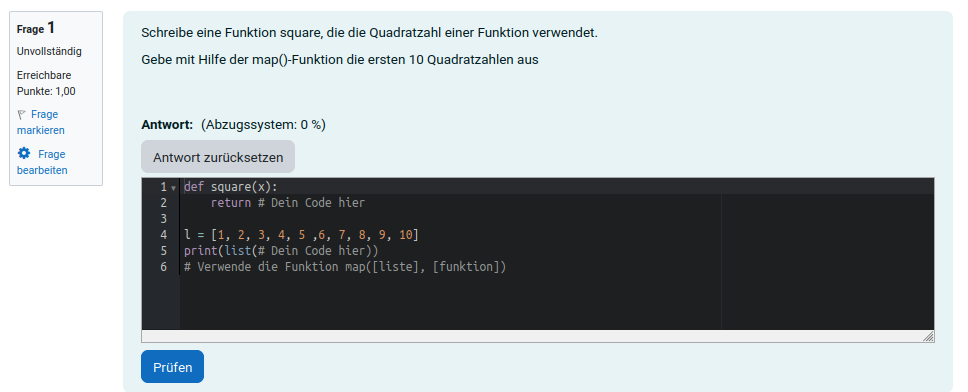

# Siehe auch...

- https://blu3r4y.github.io/python-for-java-developers/?print-pdf - Sehr umfangreife Beschreibung, wie sich Python und Java unterscheiden.
- https://cscircles.cemc.uwaterloo.ca/de/- Programmierkurs der University of Waterloo